# An Introduction to Tidy R Spatial Packages: Incorporating Historic Sociodemographic Data from the US Census and Visualizing Geographic Distributions

2024-06-12

# A. Setup and Primer

## A.1. Install Packages

First, please install any of the following packages required for this tutorial that you have not yet installed.

```r
# Spatial packages
install.packages("tidycensus")
install.packages("sf")
install.packages("ggspatial")
# Data importing, wrangling, and plotting packages
install.packages("tidyverse")
install.packages("readr")
install.packages("patchwork")
```

## A.2. Load Packages

Load the following packages that we will use in this tutorial. These packages give us functions to help with the following:

- `tidycensus`: importing Census data
- `sf`: working with and mapping spatial data
- `ggspatial`: mapping north arrow and scale bar
- `tidyverse`: data wrangling
- `readr`: importing CSV files
- `patchwork`: combining multiple maps

```r
# Spatial packages
library(tidycensus)
library(sf)
library(ggspatial)
```

```r
# Data importing, wrangling, and plotting packages
library(tidyverse)
library(readr)
library(patchwork)
```

## A.3. Obtain and Load Census API Key

In order to use the tidycensus package, we will need to load the Census API key with the `tidycensus::census_api_key()` function. You can will need to obtain and API key [here](https://api.census.gov/data/key_signup.html).

```r
tidycensus::census_api_key("[PASTE CENSUS API KEY HERE]", install = TRUE)
```

## A.4. Primer to Tutorial Syntax

When referring to a new function for the first time, we will use the double colon operator (`::`) to specify the source package of the function. For example, `dplyr::filter()` refers to the `filter()` function from the dplyr package, which is used to subset rows in a data frame that meets certain conditions (i.e., where Species is setosa).

```r
data(iris) # This loads the iris dataset

dplyr::filter(iris, Species == 'setosa')
```

| Sepal.Length | Sepal.Width | Petal.Length | Petal.Width | Species |
| --- | --- | --- | --- | --- |
| 5.1 | 3.5 | 1.4 | 0.2 | setosa |
| 4.9 | 3.0 | 1.4 | 0.2 | setosa |
| 4.7 | 3.2 | 1.3 | 0.2 | setosa |
| 4.6 | 3.1 | 1.5 | 0.2 | setosa |
| 5.0 | 3.6 | 1.4 | 0.2 | setosa |
| 5.4 | 3.9 | 1.7 | 0.4 | setosa |
| 4.6 | 3.4 | 1.4 | 0.3 | setosa |
| 5.0 | 3.4 | 1.5 | 0.2 | setosa |
| 4.4 | 2.9 | 1.4 | 0.2 | setosa |
| 4.9 | 3.1 | 1.5 | 0.1 | setosa |

[output cut: 40 more lines]

In this tutorial, we will use data wrangling functions from the [tidyverse](https://www.tidyverse.org/) collection of packages and [pipes](https://r4ds.had.co.nz/pipes.html) (`%>%`) from the magrittr package in order to clearly express sequences of steps. Piping allows us to read the code from top –> bottom rather than inside –> out.

```r
# Without pipes
head(dplyr::select(dplyr::filter(iris, Species == 'setosa'), Sepal.Length, Sepal.Width))
```

|  | Sepal.Length | Sepal.Width |
| --- | --- | --- |
| 1 | 5.1 | 3.5 |
| 2 | 4.9 | 3.0 |
| 3 | 4.7 | 3.2 |
| 4 | 4.6 | 3.1 |
| 5 | 5.0 | 3.6 |
| 6 | 5.4 | 3.9 |

```r
# With pipes
iris %>%
  dplyr::filter(Species == 'setosa') %>%
  dplyr::select(Sepal.Length, Sepal.Width) %>%
  head()
```

|  | Sepal.Length | Sepal.Width |
| --- | --- | --- |
| 1 | 5.1 | 3.5 |
| 2 | 4.9 | 3.0 |
| 3 | 4.7 | 3.2 |
| 4 | 4.6 | 3.1 |
| 5 | 5.0 | 3.6 |
| 6 | 5.4 | 3.9 |

## A.5. Set Root Directory

This code is needed so that the relative paths used in the data importing later in this code can be the same when running the code individually and knitting this RMarkdown file.

```r
knitr::opts_knit$set(root.dir = "..")
```

# B. Explore Available Census Data

You can get a list of variable names and descriptions from the U.S. Census using the `load_variables()` function from the tidycensus package. Since we are interested in the year 2021, let’s use the American Community Survey (vs. the Decennial Census data). We will use the 5-year ACS estimates and filter to variables that are available at the Census tract level.

```r
variables_2021_tract <- tidycensus::load_variables(
    year = 2021,
    dataset = "acs5",
    cache = TRUE) %>%
  dplyr::filter(geography == "tract")
variables_2021_tract %>% head()
```

| name | label | concept | geography |
| --- | --- | --- | --- |
| B01001A_001 | Estimate!!Total: | SEX BY AGE (WHITE ALONE) | tract |
| B01001A_002 | Estimate!!Total:!!Male: | SEX BY AGE (WHITE ALONE) | tract |
| B01001A_003 | Estimate!!Total:!!Male:!!Under 5 years | SEX BY AGE (WHITE ALONE) | tract |
| B01001A_004 | Estimate!!Total:!!Male:!!5 to 9 years | SEX BY AGE (WHITE ALONE) | tract |
| B01001A_005 | Estimate!!Total:!!Male:!!10 to 14 years | SEX BY AGE (WHITE ALONE) | tract |
| B01001A_006 | Estimate!!Total:!!Male:!!15 to 17 years | SEX BY AGE (WHITE ALONE) | tract |

The `str_detect()` function from the stringr package allows us to search text strings for key words. We can use it to find the variable names related to median household income and educational attainment.

- *Median household income*: We can see that the variables B06011_001 is an estimate for the median household income for the total population

```r
variables_2021_tract %>%
  dplyr::filter(concept %>% stringr::str_detect('MEDIAN INCOME'))
```

| name | label | concept | geography |
| --- | --- | --- | --- |
| B06011_001 | Estimate!!Median income in the past 12 months --!!Total: | MEDIAN INCOME IN THE PAST 12 MONTHS (IN 2021 INFLATION-ADJUSTED DOLLARS) BY PLACE OF BIRTH IN THE UNITED STATES | tract |
| B06011_002 | Estimate!!Median income in the past 12 months --!!Total:!!Born in state of residence | MEDIAN INCOME IN THE PAST 12 MONTHS (IN 2021 INFLATION-ADJUSTED DOLLARS) BY PLACE OF BIRTH IN THE UNITED STATES | tract |
| B06011_003 | Estimate!!Median income in the past 12 months --!!Total:!!Born in other state of the United States | MEDIAN INCOME IN THE PAST 12 MONTHS (IN 2021 INFLATION-ADJUSTED DOLLARS) BY PLACE OF BIRTH IN THE UNITED STATES | tract |
| B06011_004 | Estimate!!Median income in the past 12 months --!!Total:!!Native; born outside the United States | MEDIAN INCOME IN THE PAST 12 MONTHS (IN 2021 INFLATION-ADJUSTED DOLLARS) BY PLACE OF BIRTH IN THE UNITED STATES | tract |
| B06011_005 | Estimate!!Median income in the past 12 months --!!Total:!!Foreign born | MEDIAN INCOME IN THE PAST 12 MONTHS (IN 2021 INFLATION-ADJUSTED DOLLARS) BY PLACE OF BIRTH IN THE UNITED STATES | tract |
| B07011_001 | Estimate!!Median income in the past 12 months --!!Total: | MEDIAN INCOME IN THE PAST 12 MONTHS (IN 2021 INFLATION-ADJUSTED DOLLARS) BY GEOGRAPHICAL MOBILITY IN THE PAST YEAR FOR CURRENT RESIDENCE IN THE UNITED STATES | tract |
| B07011_002 | Estimate!!Median income in the past 12 months --!!Total:!!Same house 1 year ago | MEDIAN INCOME IN THE PAST 12 MONTHS (IN 2021 INFLATION-ADJUSTED DOLLARS) BY GEOGRAPHICAL MOBILITY IN THE PAST YEAR FOR CURRENT RESIDENCE IN THE UNITED STATES | tract |
| B07011_003 | Estimate!!Median income in the past 12 months --!!Total:!!Moved within same county | MEDIAN INCOME IN THE PAST 12 MONTHS (IN 2021 INFLATION-ADJUSTED DOLLARS) BY GEOGRAPHICAL MOBILITY IN THE PAST YEAR FOR CURRENT RESIDENCE IN THE UNITED STATES | tract |
| B07011_004 | Estimate!!Median income in the past 12 months --!!Total:!!Moved from different county within same state | MEDIAN INCOME IN THE PAST 12 MONTHS (IN 2021 INFLATION-ADJUSTED DOLLARS) BY GEOGRAPHICAL MOBILITY IN THE PAST YEAR FOR CURRENT RESIDENCE IN THE UNITED STATES | tract |
| B07011_005 | Estimate!!Median income in the past 12 months --!!Total:!!Moved from different state | MEDIAN INCOME IN THE PAST 12 MONTHS (IN 2021 INFLATION-ADJUSTED DOLLARS) BY GEOGRAPHICAL MOBILITY IN THE PAST YEAR FOR CURRENT RESIDENCE IN THE UNITED STATES | tract |

[output cut: 15 more lines]

```r
variables_2021_tract %>%
  dplyr::filter(concept %>% stringr::str_detect('EDUCATION'))
```

| name | label | concept | geography |
| --- | --- | --- | --- |
| B06009_001 | Estimate!!Total: | PLACE OF BIRTH BY EDUCATIONAL ATTAINMENT IN THE UNITED STATES | tract |
| B06009_002 | Estimate!!Total:!!Less than high school graduate | PLACE OF BIRTH BY EDUCATIONAL ATTAINMENT IN THE UNITED STATES | tract |
| B06009_003 | Estimate!!Total:!!High school graduate (includes equivalency) | PLACE OF BIRTH BY EDUCATIONAL ATTAINMENT IN THE UNITED STATES | tract |
| B06009_004 | Estimate!!Total:!!Some college or associate's degree | PLACE OF BIRTH BY EDUCATIONAL ATTAINMENT IN THE UNITED STATES | tract |
| B06009_005 | Estimate!!Total:!!Bachelor's degree | PLACE OF BIRTH BY EDUCATIONAL ATTAINMENT IN THE UNITED STATES | tract |
| B06009_006 | Estimate!!Total:!!Graduate or professional degree | PLACE OF BIRTH BY EDUCATIONAL ATTAINMENT IN THE UNITED STATES | tract |
| B06009_007 | Estimate!!Total:!!Born in state of residence: | PLACE OF BIRTH BY EDUCATIONAL ATTAINMENT IN THE UNITED STATES | tract |
| B06009_008 | Estimate!!Total:!!Born in state of residence:!!Less than high school graduate | PLACE OF BIRTH BY EDUCATIONAL ATTAINMENT IN THE UNITED STATES | tract |
| B06009_009 | Estimate!!Total:!!Born in state of residence:!!High school graduate (includes equivalency) | PLACE OF BIRTH BY EDUCATIONAL ATTAINMENT IN THE UNITED STATES | tract |
| B06009_010 | Estimate!!Total:!!Born in state of residence:!!Some college or associate's degree | PLACE OF BIRTH BY EDUCATIONAL ATTAINMENT IN THE UNITED STATES | tract |

[output cut: 488 more lines]

We can also use the RStudio IDE to search the variables.

```r
variables_2021_tract %>% view()
```

The `view()` function opens up the variables_2021_tract data frame containing all of the variable descriptions in a new tab. In the example below, we search for variables related to “income” by using the search bar on the top right hand side of the window.

[figure not shown]

Searching for Income

# C. Importing Data

## C.1. Census data

To download ACS data using the `get_acs()` function, we need three pieces of information.

- First, what do we want our geography to be? What’s our unit of analysis? For this we have decided to use the Census tracts of New York State. See a full list of available geographies here: https://walker-data.com/tidycensus/articles/basic-usage.html#geography-in-tidycensus
- Second, what variables do we want? We can pull those directly in using the same command line. We can even give it our own titles.
- Third, what year of data do we want? There’s room for that too!

Let’s use median income in the past 12 months (B06011_001) and educational attainment (B06009_001, B06009_002, B06009_003, B06009_004, B06009_005).

### C.1.1. Tabular Census Data

```r
acs_data_prelim <- get_acs(
  geography = "tract",
  variables = c(hhincome = "B06011_001",
                total_education = "B06009_001",
                education_lessthanhs = "B06009_002",
                education_hs = "B06009_003",
                education_somecollege = "B06009_004",
                education_bachelors = "B06009_005"),
  state = "NY",
  year = 2021,
  output = "wide")
acs_data_prelim %>% head()
```

| GEOID | NAME | hhincomeE | hhincomeM | total_educationE | total_educationM | education_lessthanhsE | education_lessthanhsM | education_hsE | education_hsM | education_somecollegeE | education_somecollegeM | education_bachelorsE | education_bachelorsM |
| --- | --- | --- | --- | --- | --- | --- | --- | --- | --- | --- | --- | --- | --- |
| 36001000100 | Census Tract 1, Albany County, New York | 22492 | 3707 | 1201 | 178 | 295 | 101 | 340 | 109 | 281 | 100 | 186 | 70 |
| 36001000201 | Census Tract 2.01, Albany County, New York | 29178 | 6483 | 1886 | 417 | 221 | 131 | 421 | 179 | 533 | 239 | 458 | 245 |
| 36001000202 | Census Tract 2.02, Albany County, New York | 17970 | 3733 | 1499 | 568 | 234 | 149 | 500 | 223 | 679 | 502 | 78 | 100 |
| 36001000301 | Census Tract 3.01, Albany County, New York | 25080 | 15241 | 1954 | 421 | 273 | 125 | 726 | 237 | 729 | 283 | 63 | 66 |
| 36001000302 | Census Tract 3.02, Albany County, New York | 34787 | 10404 | 2413 | 408 | 109 | 105 | 549 | 238 | 764 | 309 | 455 | 205 |
| 36001000401 | Census Tract 4.01, Albany County, New York | 37554 | 7531 | 2119 | 308 | 75 | 36 | 455 | 174 | 537 | 163 | 396 | 141 |

```r
# Check: The above command brings in the data as a dataframe, which means there is no geometry attached
class(acs_data_prelim)
```

```
## [1] "tbl_df"     "tbl"        "data.frame"
```

### C.1.2. Spatial Census Data

Now first we downloaded the ACS data using tidycensus, but it was just a dataframe. This means there was no spatial component attached. The good news about get_acs() is that we can also ask it to bring in geometries – an essential tool to make a map!

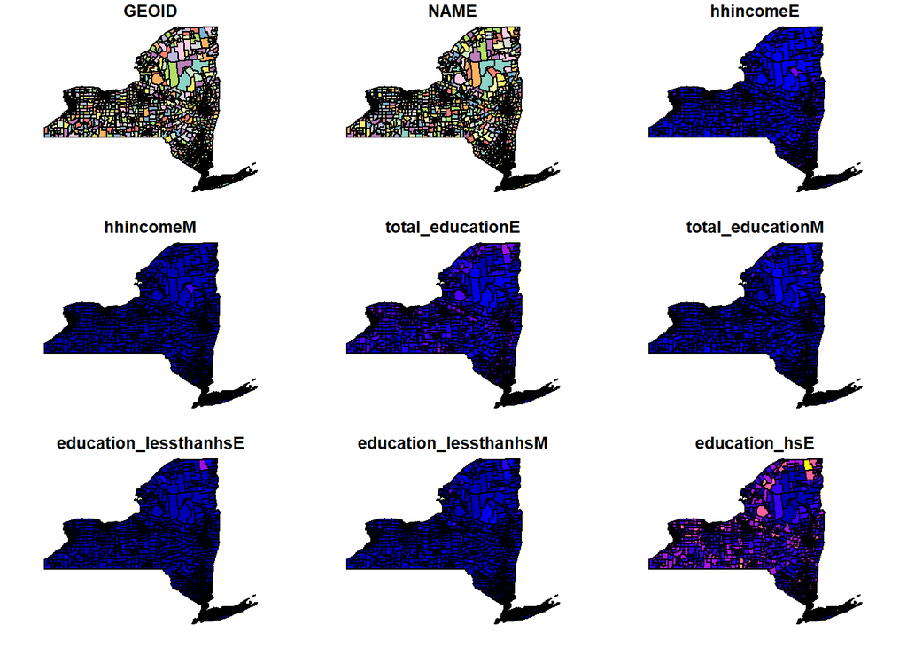

```r
acs_data_geo_prelim <- get_acs(
    geography = "tract",
    variables = c(hhincome = "B06011_001",
                  total_education = "B06009_001",
                  education_lessthanhs= "B06009_002",
                  education_hs = "B06009_003",
                  education_somecollege = "B06009_004",
                  education_bachelors = "B06009_005"),
    state = "NY",
    year = 2021,
    output = "wide",
    geometry = TRUE) # To also bring in geometries, add in the geometry = TRUE function
acs_data_geo_prelim %>% view()
plot(acs_data_geo_prelim)
```

## C.2. PLACES Data (health outcomes)

The [PLACES data](https://www.cdc.gov/places/index.html) was prepared by the Centers for Disease Control and Prevention (CDC), Robert Wood Johnson Foundation, and the CDC Foundation.

You can use the `sf::st_read()` function in order to import spatial data files into R. You can see that the file imported is a “simple feature”, which is a spatial data format in R.

```r
places_sf <- sf::st_read('data/places2023-spatial/places2023.shp')
```

We have prepared a subset of the data in a CSV file that contains only the coronary heart disease (CHD) prevalence for the state of New York. We will use the `readr::read_csv()` function to join this tabular data with the spatial Census data that we imported earlier.

```r
places_prelim <- readr::read_csv("data/places2023_ny_chd.csv")
```

# D. Cleaning Data

## D.2. PLACES

Next, we can looking at the column data types in the Census and PLACES data frames using the `str()` functions. We can see that the unique identifier for each Census tract, GEOID, is a character column in the Census data but a numeric column in the PLACES data.

```r
acs_data_geo %>% str()
```

```
## Classes 'sf' and 'data.frame':   5411 obs. of  7 variables:
##  $ GEOID           : chr  "36081014700" "36047058400" "36061006900" "36047073000" ...
##  $ hhincome        : num  48780 41056 110455 38690 42545 ...
##  $ perc_lessthanhs : num  0.1173 0.1039 0 0.0489 0.0588 ...
##  $ perc_hs         : num  0.2027 0.2318 0.0549 0.2436 0.3023 ...
##  $ perc_somecollege: num  0.1745 0.1454 0.0807 0.2416 0.2368 ...
##  $ perc_bachelors  : num  0.316 0.287 0.486 0.345 0.243 ...
##  $ geometry        :sfc_MULTIPOLYGON of length 5411; first list element: List of 1
##   ..$ :List of 1
##   .. ..$ : num [1:14, 1:2] -73.9 -73.9 -73.9 -73.9 -73.9 ...
##   ..- attr(*, "class")= chr [1:3] "XY" "MULTIPOLYGON" "sfg"
##  - attr(*, "sf_column")= chr "geometry"
##  - attr(*, "agr")= Factor w/ 3 levels "constant","aggregate",..: NA NA NA NA NA NA
##   ..- attr(*, "names")= chr [1:6] "GEOID" "hhincome" "perc_lessthanhs" "perc_hs" ...
```

```r
places_prelim %>% str()
```

```
## spc_tbl_ [4,840 × 3] (S3: spec_tbl_df/tbl_df/tbl/data.frame)
##  $ GEOID   : num [1:4840] 3.6e+10 3.6e+10 3.6e+10 3.6e+10 3.6e+10 ...
##  $ state   : chr [1:4840] "NY" "NY" "NY" "NY" ...
##  $ chd_prev: num [1:4840] 0.046 0.057 0.067 0.064 0.067 0.057 0.054 0.052 0.064 0.041 ...
##  - attr(*, "spec")=
##   .. cols(
##   ..   GEOID = col_double(),
##   ..   state = col_character(),
##   ..   chd_prev = col_double()
##   .. )
##  - attr(*, "problems")=<externalptr>
```

We will join the Census and PLACES data together by GEOID, so we will need to convert GEOID in the PLACES data to a character column since GEOID will need to be the same data type for a successful table join.

```r
places <- places_prelim %>%
  dplyr::transmute(GEOID = GEOID %>% as.character(),
                   chd_prev)
```

## D.2. Merge Data

Use the `dplyr::left_join()` function in order to conduct a table join for the geographic Census data with the PLACES data.

```r
merged <- acs_data_geo %>%
  dplyr::left_join(places, by = 'GEOID')
```

# E. Exploring the Data

### E.1. A Snapshot of 2021

Let’s begin by exploring the data. We can do that with `summary()` function or a variety of data visualization techniques.

A histogram visually represents the distribution of a dataset by grouping data into bins and displaying the frequency of data points within each bin.

```r
# Explore data
acs_data %>%
  dplyr::select(perc_lessthanhs, perc_hs, perc_somecollege, perc_bachelors) %>%
  summary()
```

```
##  perc_lessthanhs      perc_hs       perc_somecollege perc_bachelors
##  Min.   :0.00000   Min.   :0.0000   Min.   :0.0000   Min.   :0.0000
##  1st Qu.:0.05360   1st Qu.:0.1922   1st Qu.:0.1892   1st Qu.:0.1301
##  Median :0.09948   Median :0.2676   Median :0.2495   Median :0.1919
##  Mean   :0.12877   Mean   :0.2622   Mean   :0.2469   Mean   :0.2035
##  3rd Qu.:0.17491   3rd Qu.:0.3357   3rd Qu.:0.3064   3rd Qu.:0.2640
##  Max.   :1.00000   Max.   :1.0000   Max.   :1.0000   Max.   :0.7143
##  NA's   :115       NA's   :115      NA's   :115      NA's   :115
```

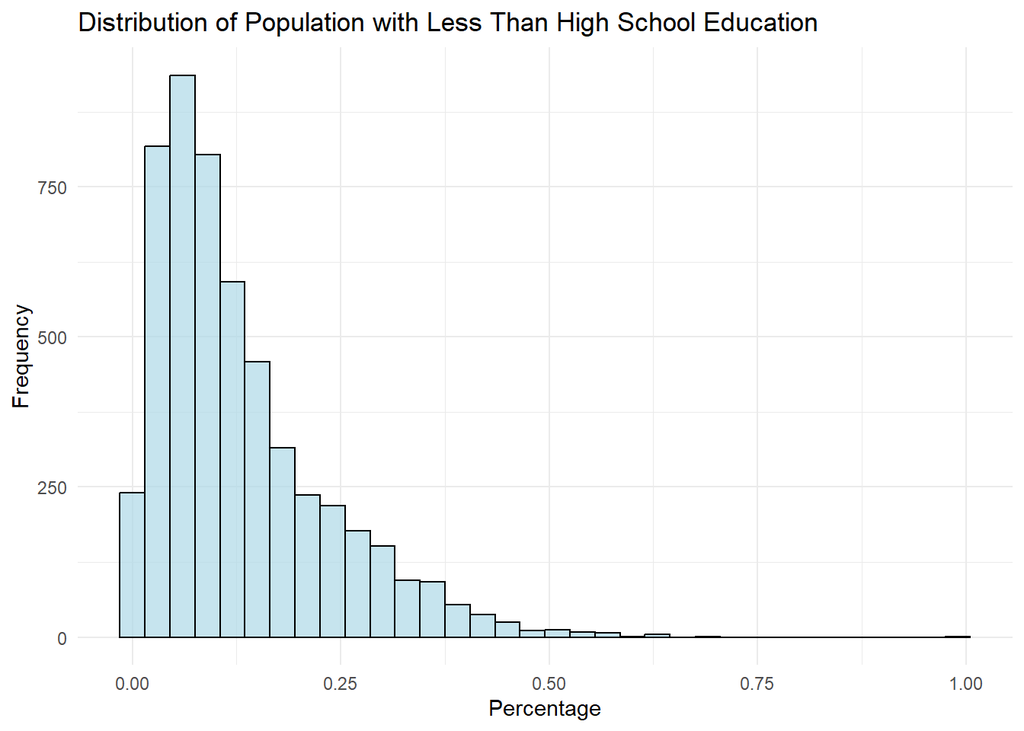

```r
# Histogram for distribution of population with less than high school education across census tracts
plot_hist <- ggplot(acs_data, aes(x = perc_lessthanhs)) +
  geom_histogram(binwidth = 0.03, fill = "lightblue", color = "black", alpha = 0.7) +
  theme_minimal() +
  labs(title = "Distribution of Population with Less Than High School Education",
       x = "Percentage",
       y = "Frequency")

plot_hist
```

A box plot, or box-and-whisker plot, displays the distribution of a dataset by showing its median, quartiles, and potential outliers.

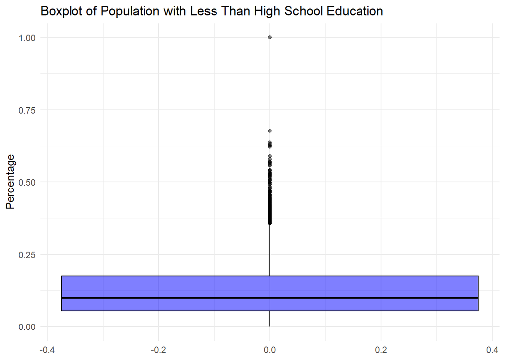

```r
# Boxplot for percentage of population with a  high school degree across census tracts
plot_box <- ggplot(acs_data, aes(y = perc_lessthanhs)) +
  geom_boxplot(fill = "blue", color = "black", alpha = 0.5) +
  theme_minimal() +
  labs(title = "Boxplot of Population with Less Than High School Education",
       y = "Percentage")

plot_box
```

A bar plot represents categorical data with rectangular bars, where the height or length of each bar is proportional to the value it represents.

```r
# Bar plots for percentages

# Reshape the data for easier plotting
education_data <- acs_data %>%
  select(GEOID, perc_lessthanhs, perc_hs, perc_somecollege, perc_bachelors) %>%
  pivot_longer(cols = starts_with("perc_"), names_to = "education_level", values_to = "proportion")

print(head(education_data))
```

```
## # A tibble: 6 × 3
##   GEOID       education_level  proportion
##   <chr>       <chr>                 <dbl>
## 1 36001000100 perc_lessthanhs       0.246
## 2 36001000100 perc_hs               0.283
## 3 36001000100 perc_somecollege      0.234
## 4 36001000100 perc_bachelors        0.155
## 5 36001000201 perc_lessthanhs       0.117
## 6 36001000201 perc_hs               0.223
```

```r
summary(education_data$proportion)
```

```
##    Min. 1st Qu.  Median    Mean 3rd Qu.    Max.    NA's
##  0.0000  0.1212  0.2096  0.2103  0.2900  1.0000     460
```

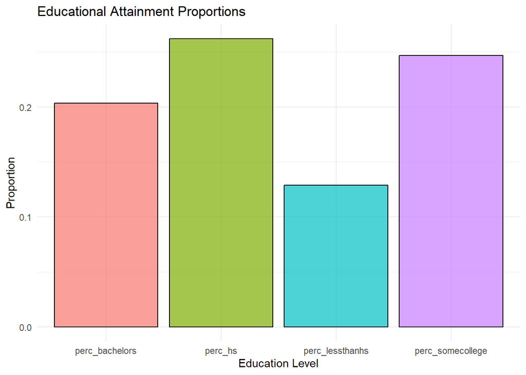

```r
# Bar plot for educational attainment percentages
plot_bar <- education_data %>%
  dplyr::group_by(education_level) %>%
  dplyr::summarize(mean_proportion = mean(proportion, na.rm = TRUE)) %>%
  ggplot(aes(x = education_level, y = mean_proportion, fill = education_level)) +
  geom_bar(stat = 'identity', color = "black", alpha = 0.7) +
  theme_minimal() +
  labs(title = "Educational Attainment Proportions",
       x = "Education Level",
       y = "Proportion") +
  theme(legend.position = "none")

plot_bar
```